# QTM 151 - Introduction to Statistical Computing II

Lecture 20 - Joining Tables in SQL

Danilo Freire

danilo.freire@emory.edu

Emory University

11 October, 2024

# Hi! 😊 Hope your week is going well

# Brief recap of lecture 19 📚

## Some updates on the final project

- The list of groups is now available on our reppository. [Check it out here](https://github.com/danilofreire/qtm151/blob/main/final-project/groups.ipynb)
- All groups have 3-4 members, as we discussed
- Many thanks to all of you who have already formed your groups and sent them to me! 🙏🏻
- Those not in a group have been assigned to one at random
- So please check the list and make sure you are in a group, and that you know your group members
- Any questions? 😊

## Brief recap of last lecture

### Last time, we learned how to:

- Use `psycopg2` to connect to a PostgreSQL database
- Use `sqlalchemy` and `pandas` to run SQL queries in Python
- Use `pandas` to convert files to SQL tables and vice-versa
- And we also learned how to use Python functions with SQL queries

[figure not shown]

# Today’s plan 📋

## Merge tables in SQL

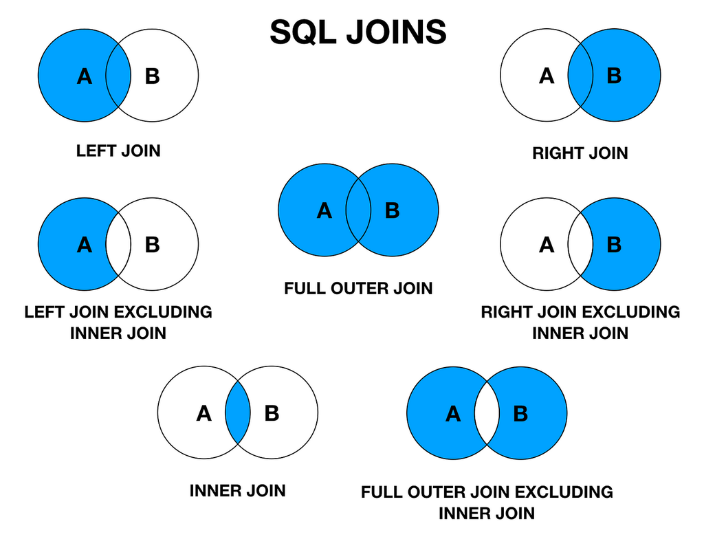

# Merging tables in SQL 📊

## The `JOIN` statement

- The `JOIN` statement is used to combine rows from two or more tables, based on a related column between them (usually a primary key)
- `JOIN` is very flexible and can be used in many ways for pretty much all types of data merge operations
- The most common types of joins are:
  - `INNER JOIN`
  - `LEFT JOIN`
  - `RIGHT JOIN`
  - `FULL JOIN`
  - `CROSS JOIN`
  - `SELF JOIN`
- `LEFT JOIN` is probably the most common type of join
- You keep all rows from the left table and only the matching rows from the right table
- The syntax is as follows:
- `SELECT * FROM table1 LEFT JOIN table2 ON table1.column = table2.column`
- The `ON` clause specifies the condition to join the tables, i.e., the column(s) that are common to both tables
- The `LEFT JOIN` keyword returns all records from the left table (table1), and the matched records from the right table (table2)
- The result is `NULL` from the right side if there is no match
- Let’s see an example to make it clearer 😊

## Set up the environment 🛠️

- Let’s start by loading the necessary libraries

```python
# Load the necessary libraries
import pandas as pd
import psycopg2
from sqlalchemy import create_engine, text

# Connect to the database
engine = create_engine('postgresql+psycopg2://postgres:postgres@localhost:5432/postgres')
conn = engine.connect()
```

- Then let’s create two tables that we will use to test the `JOIN` clauses
- Issues with the code? Please have a look at the appendix

```python
# Rollback any existing transactions
conn.rollback()

# Drop the tables if they already exist
conn.execute(text('DROP TABLE IF EXISTS famous_people CASCADE'))

conn.execute(text('DROP TABLE IF EXISTS information CASCADE'))

# Create tables in the SQL database
conn.execute(text('''
CREATE TABLE IF NOT EXISTS famous_people (
    person_id INTEGER PRIMARY KEY,
    name TEXT
)
'''))

conn.execute(text('''
CREATE TABLE IF NOT EXISTS information (
    person_id INTEGER,
    country TEXT,
    profession TEXT
)
'''))

# Insert data into the tables
conn.execute(text('''
INSERT INTO famous_people (person_id, name) VALUES
  (1, 'Albert Einstein'),
  (2, 'Isaac Newton'),
  (3, 'Marie Curie'),
  (4, 'Galileo Galilei'),
  (5, 'René Descartes'),
  (6, 'Blaise Pascal'),
  (7, 'Nikola Tesla')
'''))

conn.execute(text('''
INSERT INTO information (person_id, country, profession) VALUES
  (1, 'Germany', 'Physicist'),
  (2, 'United Kingdom', 'Mathematician'),
  (3, 'Poland', 'Physicist'),
  (4, 'Italy', 'Astronomer'),
  (5, 'France', 'Philosopher'),
  (6, 'France', 'Mathematician')
'''))

conn.commit()
conn.close()
```

## Let’s see the tables

- Let’s see the tables we just created

```python
# Connect to the database
conn = engine.connect()
pd.read_sql_query("SELECT * FROM famous_people", conn)
```

|  | person_id | name |
| --- | --- | --- |
| 0 | 1 | Albert Einstein |
| 1 | 2 | Isaac Newton |
| 2 | 3 | Marie Curie |
| 3 | 4 | Galileo Galilei |
| 4 | 5 | René Descartes |
| 5 | 6 | Blaise Pascal |
| 6 | 7 | Nikola Tesla |

```python
pd.read_sql_query("SELECT * FROM information", conn)
```

|  | person_id | country | profession |
| --- | --- | --- | --- |
| 0 | 1 | Germany | Physicist |
| 1 | 2 | United Kingdom | Mathematician |
| 2 | 3 | Poland | Physicist |
| 3 | 4 | Italy | Astronomer |
| 4 | 5 | France | Philosopher |
| 5 | 6 | France | Mathematician |

## Error handling 🚨

- `sqlalchemy` sometimes produces some unexpected behaviours when running SQL queries
- In my experience, it sometimes fails to run queries that are too long or too complex
- The worst thing is, it just keeps running forever without giving any error message! 🤬
- So if you run a query and it takes too long, or if you suspect it is not working, just interrupt the kernel and try again
- A good idea is to add `conn.rollback()` before running the query, to make sure the connection is clean
- If you would like to save the data, it is also a good idea to run `conn.commit()` to make sure the data is saved
- Then, close the connection to prevent memory leaks with `conn.close()`
- The bad news is that you have to recreate the connection every time you encounter an error
- If you typed `conn.commit()`, the table will indeed be in the database, so you won’t need to recreate it
- But if you didn’t, you will need to recreate the table and insert the data again
- So far I haven’t found a way to fix this error (it seems to happen quite often with others too), but I will keep looking for a solution 😊
- Check this appendix for a workaround

## Let’s join the tables with `LEFT JOIN` 🤝

- Now that we have the tables, let’s join them using the `LEFT JOIN` clause

```python
pd.read_sql("""
    SELECT *
    FROM famous_people
    LEFT JOIN information
    ON famous_people.person_id = information.person_id
""", conn)
```

|  | person_id | name | person_id | country | profession |
| --- | --- | --- | --- | --- | --- |
| 0 | 1 | Albert Einstein | 1.0 | Germany | Physicist |
| 1 | 2 | Isaac Newton | 2.0 | United Kingdom | Mathematician |
| 2 | 3 | Marie Curie | 3.0 | Poland | Physicist |
| 3 | 4 | Galileo Galilei | 4.0 | Italy | Astronomer |
| 4 | 5 | René Descartes | 5.0 | France | Philosopher |
| 5 | 6 | Blaise Pascal | 6.0 | France | Mathematician |
| 6 | 7 | Nikola Tesla | NaN | None | None |

## Let’s join the tables with `INNER JOIN` 🤝

- Now let’s join the tables using the `INNER JOIN` clause

```python
pd.read_sql("""
SELECT *
FROM famous_people
INNER JOIN information
ON famous_people.person_id = information.person_id
""", conn)
```

|  | person_id | name | person_id | country | profession |
| --- | --- | --- | --- | --- | --- |
| 0 | 1 | Albert Einstein | 1 | Germany | Physicist |
| 1 | 2 | Isaac Newton | 2 | United Kingdom | Mathematician |
| 2 | 3 | Marie Curie | 3 | Poland | Physicist |
| 3 | 4 | Galileo Galilei | 4 | Italy | Astronomer |
| 4 | 5 | René Descartes | 5 | France | Philosopher |
| 5 | 6 | Blaise Pascal | 6 | France | Mathematician |

# Entity Relationship Diagram (ERD) 📊

## What is an ERD?

- An Entity Relationship Diagram (ERD) is a visual representation of the relationships between entities in a database
- ERDs are used to model the logical structure of a database
- Their main function is to indicate which entities (variables) are related to each other and how they are related
- So they should always indicate the primary keys and foreign keys of the tables
- A primary key is a unique identifier for each row in a table
- A foreign key is a column that references the primary key of another table
- Tables don’t need to have a foreign key, but they usually do as it helps to maintain data integrity

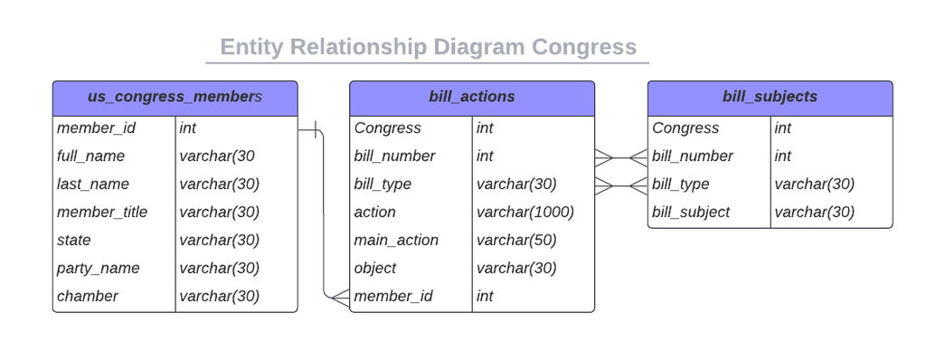

Click on the image to enlarge

- For instance, if we have a table with information about members of the US Congress, we could have the following ERD
- Note the connections between the tables, which indicate the relationships between them

## Let’s see another example with bigger tables 📊

- This time, we will load two `.csv` files into the database
- We will then join the tables using the `LEFT JOIN` clause

```python
# Load the data
bills_actions       = pd.read_csv("data_raw/bills_actions.csv")
us_congress_members = pd.read_csv("data_raw/us_congress_members.csv")

# Recreate the connection
conn = engine.connect()

# Rollback any existing transactions
conn.rollback()

# Drop the tables if they already exist
conn.execute(text('DROP TABLE IF EXISTS bills_actions CASCADE'))
conn.execute(text('DROP TABLE IF EXISTS us_congress_members CASCADE'))
conn.commit()

# Create the tables in the database
bills_actions.to_sql("bills_actions", conn, if_exists="replace", index=False)
us_congress_members.to_sql("us_congress_members", conn, if_exists="replace", index=False)
conn.commit()
```

## Let’s see the table 📊

```python
# Recreate the connection
conn = engine.connect()

# Rollback any existing transactions
conn.rollback()

# Check if the table exists
pd.read_sql(text('SELECT * FROM bills_actions'), conn).head()
```

|  | congress | bill_number | bill_type | action | main_action | object | member_id |
| --- | --- | --- | --- | --- | --- | --- | --- |
| 0 | 116 | 1029 | s | S.Amdt.1274 Amendment SA 1274 proposed by Sena... | senate amendment proposed (on the floor) | amendment | 858 |
| 1 | 116 | 1031 | s | S.Amdt.2698 Amendment SA 2698 proposed by Sena... | senate amendment proposed (on the floor) | amendment | 675 |
| 2 | 116 | 1160 | s | S.Amdt.2659 Amendment SA 2659 proposed by Sena... | senate amendment proposed (on the floor) | amendment | 858 |
| 3 | 116 | 1199 | s | Committee on Health, Education, Labor, and Pen... | senate committee/subcommittee actions | senate bill | 1561 |
| 4 | 116 | 1208 | s | Committee on the Judiciary. Reported by Senato... | senate committee/subcommittee actions | senate bill | 1580 |

## Try it yourself! 🤓

- Download and display the `us_congress_members` dataset from SQL
- Be sure to use `conn.rollback()` before running the query to clean the connection
- If you encounter an error, check the appendix or ask me for help 😊
- Click here to see the solution

## Merging the tables 🤝

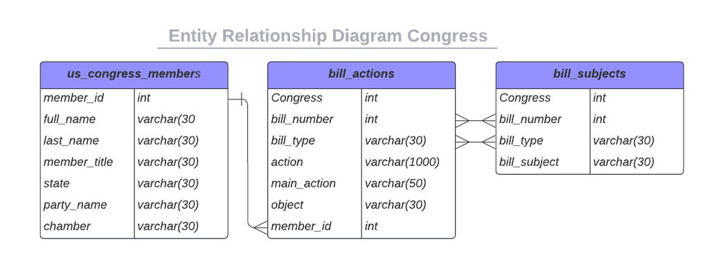

Click on the image to enlarge

- Here `member_id` is the `PRIMARY KEY` of the first dataset
- We can check that with SQL commands

```python
# Recreate the connection
engine = create_engine('postgresql://postgres:postgres@localhost:5432/postgres')
conn = engine.connect()

# Rollback any existing transactions
conn.rollback()

# Check if the table exists and count distinct member_id
results = pd.read_sql(text('''
  SELECT COUNT(DISTINCT member_id) AS num_distinct,
  COUNT(*) AS num_members
  FROM us_congress_members
'''), conn)

print(results)

conn.close()
```

```
   num_distinct  num_members
0          1811         1811
```

## Try it yourself! 🤓

- Merge two datasets
- Similar to Python
- `FROM` is followed by the name of the primary dataset
- `LEFT` is followed by the name of the secondary dataset
- `ON` is the id variable used for merging
- Click here to see the solution

## Appendix 01 - Error handling 🚨

- If you encounter an error when running the code, you can use the following workaround
- First, you can rollback the transaction to clean the connection
- Add this before running the query

```python
conn.rollback()
```

- If you want to save the data, you can commit the transaction
- Add this after running the query

```python
conn.commit()
```

- Finally, close the connection to prevent memory leaks

```python
conn.close()
```

## Appendix 01 - Error handling 🚨

- If everything else fails, you can drop all tables and recreate them
- This code will clean your database

```python
from sqlalchemy import create_engine, text, inspect
import time

engine = create_engine('postgresql+psycopg2://postgres:postgres@localhost:5432/postgres', future=True)
connection = engine.connect()

def clean_database(engine):
    with engine.connect() as conn:
        try:
            # Get inspector to check existing tables
            inspector = inspect(engine)
            existing_tables = inspector.get_table_names()

            if not existing_tables:
                print("No tables found in database")
                return

            print(f"Found {len(existing_tables)} tables: {existing_tables}")

            # Kill other connections
            conn.execute(text("""
                SELECT pg_terminate_backend(pid)
                FROM pg_stat_activity
                WHERE pid <> pg_backend_pid()
                AND datname = current_database()
            """))

            conn.execute(text("ROLLBACK"))
            conn.execute(text("SET statement_timeout = '30s'"))

            # Only drop tables that exist
            for table in existing_tables:
                try:
                    conn.execute(text(f"DROP TABLE IF EXISTS {table} CASCADE"))
                    print(f"Dropped {table}")
                    conn.commit()
                    time.sleep(1)
                except Exception as e:
                    print(f"Error with {table}: {str(e)}")
                    conn.execute(text("ROLLBACK"))

        except Exception as e:
            print(f"Fatal error: {str(e)}")
            conn.execute(text("ROLLBACK"))

# Execute
clean_database(engine)
```

Back to the lecture

## Appendix 02

- Download and display the `us_congress_members` dataset from SQL

```python
# Recreate the connection
conn = engine.connect()

# Rollback any existing transactions
conn.rollback()

# Drop the tables if they already exist
conn.execute(text('''
DROP TABLE IF EXISTS us_congress_members CASCADE
'''))
conn.commit()

# Import "races"
us_congress_members.to_sql('us_congress_members',
             con = conn,
             if_exists='replace',
             index=False)

conn.commit()

# Check if the table exists
pd.read_sql_query("SELECT * FROM us_congress_members", conn)
```

|  | member_id | full_name | last_name | member_title | state | party_name | chamber |
| --- | --- | --- | --- | --- | --- | --- | --- |
| 0 | 0 | A. Donald McEachin | McEachin | Representative | Virginia | Democratic | House |
| 1 | 1 | Aaron Schock | Schock | Representative | Illinois | Republican | House |
| 2 | 2 | Abby Finkenauer | Finkenauer | Representative | Iowa | Democratic | House |
| 3 | 3 | Abigail Davis Spanberger | Spanberger | Representative | Virginia | Democratic | House |
| 4 | 4 | Adam H. Putnam | Putnam | Representative | Florida | Republican | House |
| ... | ... | ... | ... | ... | ... | ... | ... |
| 1806 | 1806 | Wm. Lacy Clay | Clay | Representative | Missouri | Democratic | House |
| 1807 | 1807 | Wyche, Jr. Fowler | Fowler | Senator | Georgia | Democratic | House |
| 1808 | 1808 | Wyche, Jr. Fowler | Fowler | Senator | Georgia | Democratic | Senate |
| 1809 | 1809 | Yvette D. Clarke | Clarke | Representative | New York | Democratic | House |
| 1810 | 1810 | Zell Miller | Miller | Senator | Georgia | Democratic | Senate |

1811 rows × 7 columns

Back to the lecture

## Appendix 03

- Merge two datasets
- Similar to Python
- `FROM` is followed by the name of the primary dataset
- `LEFT` is followed by the name of the secondary dataset
- `ON` is the id variable used for merging
- Here we are merging the `us_congress_members` dataset with the `bills_actions` dataset

```python
# Restart the connection
conn = engine.connect()

# Rollback any existing transactions
conn.rollback()

# Merge the tables
results = pd.read_sql('''
SELECT *
FROM us_congress_members
LEFT JOIN bills_actions
ON us_congress_members.member_id = bills_actions.member_id
''', conn)

print(results.head())

conn.close()
```

```
   member_id                 full_name   last_name    member_title     state  \
0          0        A. Donald McEachin    McEachin  Representative  Virginia
1          1              Aaron Schock      Schock  Representative  Illinois
2          2           Abby Finkenauer  Finkenauer  Representative      Iowa
3          2           Abby Finkenauer  Finkenauer  Representative      Iowa
4          3  Abigail Davis Spanberger  Spanberger  Representative  Virginia

   party_name chamber  congress  bill_number bill_type  \
0  Democratic   House       NaN          NaN      None
1  Republican   House       NaN          NaN      None
2  Democratic   House     116.0          3.0        hr
3  Democratic   House     116.0       7617.0        hr
4  Democratic   House     116.0       1644.0        hr

                                              action              main_action  \
0                                               None                     None
1                                               None                     None
2  H.Amdt.719 Amendment (A009) offered by Ms. Fin...  house amendment offered
3  H.Amdt.870 Amendment (A012) offered by Ms. Fin...  house amendment offered
4  H.Amdt.167 Amendment (A011) offered by Ms. Spa...  house amendment offered

      object  member_id
0       None        NaN
1       None        NaN
2  amendment        2.0
3  amendment        2.0
4  amendment        3.0
```

Back to the lecture